# LAB1

```python
import pandas as pd
import numpy as np

import matplotlib.pyplot as plt
import seaborn as sns

air_quality = pd.read_csv("city_day.csv")
crop_production = pd.read_csv("crop_production.csv")
```

```python
air_quality.head()
```

|  | City | Date | PM2.5 | PM10 | NO | NO2 | NOx | NH3 | CO | SO2 | O3 | Benzene | Toluene | Xylene | AQI | AQI_Bucket |
| --- | --- | --- | --- | --- | --- | --- | --- | --- | --- | --- | --- | --- | --- | --- | --- | --- |
| 0 | Ahmedabad | 2015-01-01 | NaN | NaN | 0.92 | 18.22 | 17.15 | NaN | 0.92 | 27.64 | 133.36 | 0.00 | 0.02 | 0.00 | NaN | NaN |
| 1 | Ahmedabad | 2015-01-02 | NaN | NaN | 0.97 | 15.69 | 16.46 | NaN | 0.97 | 24.55 | 34.06 | 3.68 | 5.50 | 3.77 | NaN | NaN |
| 2 | Ahmedabad | 2015-01-03 | NaN | NaN | 17.40 | 19.30 | 29.70 | NaN | 17.40 | 29.07 | 30.70 | 6.80 | 16.40 | 2.25 | NaN | NaN |
| 3 | Ahmedabad | 2015-01-04 | NaN | NaN | 1.70 | 18.48 | 17.97 | NaN | 1.70 | 18.59 | 36.08 | 4.43 | 10.14 | 1.00 | NaN | NaN |
| 4 | Ahmedabad | 2015-01-05 | NaN | NaN | 22.10 | 21.42 | 37.76 | NaN | 22.10 | 39.33 | 39.31 | 7.01 | 18.89 | 2.78 | NaN | NaN |

```python
air_quality.shape
```

```
(29531, 16)
```

```python
air_quality.info()
```

```
<class 'pandas.core.frame.DataFrame'>
RangeIndex: 29531 entries, 0 to 29530
Data columns (total 16 columns):
 #   Column      Non-Null Count  Dtype
---  ------      --------------  -----
 0   City        29531 non-null  object
 1   Date        29531 non-null  object
 2   PM2.5       24933 non-null  float64
 3   PM10        18391 non-null  float64
 4   NO          25949 non-null  float64
 5   NO2         25946 non-null  float64
 6   NOx         25346 non-null  float64
 7   NH3         19203 non-null  float64
 8   CO          27472 non-null  float64
 9   SO2         25677 non-null  float64
 10  O3          25509 non-null  float64
 11  Benzene     23908 non-null  float64
 12  Toluene     21490 non-null  float64
 13  Xylene      11422 non-null  float64
 14  AQI         24850 non-null  float64
 15  AQI_Bucket  24850 non-null  object
dtypes: float64(13), object(3)
memory usage: 3.6+ MB
```

```python
air_quality.describe()
```

|  | PM2.5 | PM10 | NO | NO2 | NOx | NH3 | CO | SO2 | O3 | Benzene | Toluene | Xylene | AQI |
| --- | --- | --- | --- | --- | --- | --- | --- | --- | --- | --- | --- | --- | --- |
| count | 24933.000000 | 18391.000000 | 25949.000000 | 25946.000000 | 25346.000000 | 19203.000000 | 27472.000000 | 25677.000000 | 25509.000000 | 23908.000000 | 21490.000000 | 11422.000000 | 24850.000000 |
| mean | 67.450578 | 118.127103 | 17.574730 | 28.560659 | 32.309123 | 23.483476 | 2.248598 | 14.531977 | 34.491430 | 3.280840 | 8.700972 | 3.070128 | 166.463581 |
| std | 64.661449 | 90.605110 | 22.785846 | 24.474746 | 31.646011 | 25.684275 | 6.962884 | 18.133775 | 21.694928 | 15.811136 | 19.969164 | 6.323247 | 140.696585 |
| min | 0.040000 | 0.010000 | 0.020000 | 0.010000 | 0.000000 | 0.010000 | 0.000000 | 0.010000 | 0.010000 | 0.000000 | 0.000000 | 0.000000 | 13.000000 |
| 25% | 28.820000 | 56.255000 | 5.630000 | 11.750000 | 12.820000 | 8.580000 | 0.510000 | 5.670000 | 18.860000 | 0.120000 | 0.600000 | 0.140000 | 81.000000 |
| 50% | 48.570000 | 95.680000 | 9.890000 | 21.690000 | 23.520000 | 15.850000 | 0.890000 | 9.160000 | 30.840000 | 1.070000 | 2.970000 | 0.980000 | 118.000000 |
| 75% | 80.590000 | 149.745000 | 19.950000 | 37.620000 | 40.127500 | 30.020000 | 1.450000 | 15.220000 | 45.570000 | 3.080000 | 9.150000 | 3.350000 | 208.000000 |
| max | 949.990000 | 1000.000000 | 390.680000 | 362.210000 | 467.630000 | 352.890000 | 175.810000 | 193.860000 | 257.730000 | 455.030000 | 454.850000 | 170.370000 | 2049.000000 |

```python
air_quality.isnull().sum()
```

```
City              0
Date              0
PM2.5          4598
PM10          11140
NO             3582
NO2            3585
NOx            4185
NH3           10328
CO             2059
SO2            3854
O3             4022
Benzene        5623
Toluene        8041
Xylene        18109
AQI            4681
AQI_Bucket     4681
dtype: int64
```

```python
crop_production.head()
```

|  | State_Name | District_Name | Crop_Year | Season | Crop | Area | Production |
| --- | --- | --- | --- | --- | --- | --- | --- |
| 0 | Andaman and Nicobar Islands | NICOBARS | 2000 | Kharif | Arecanut | 1254.0 | 2000.0 |
| 1 | Andaman and Nicobar Islands | NICOBARS | 2000 | Kharif | Other Kharif pulses | 2.0 | 1.0 |
| 2 | Andaman and Nicobar Islands | NICOBARS | 2000 | Kharif | Rice | 102.0 | 321.0 |
| 3 | Andaman and Nicobar Islands | NICOBARS | 2000 | Whole Year | Banana | 176.0 | 641.0 |
| 4 | Andaman and Nicobar Islands | NICOBARS | 2000 | Whole Year | Cashewnut | 720.0 | 165.0 |

```python
crop_production.shape
```

```
(246091, 7)
```

```python
crop_production.info()
```

```
<class 'pandas.core.frame.DataFrame'>
RangeIndex: 246091 entries, 0 to 246090
Data columns (total 7 columns):
 #   Column         Non-Null Count   Dtype
---  ------         --------------   -----
 0   State_Name     246091 non-null  object
 1   District_Name  246091 non-null  object
 2   Crop_Year      246091 non-null  int64
 3   Season         246091 non-null  object
 4   Crop           246091 non-null  object
 5   Area           246091 non-null  float64
 6   Production     242361 non-null  float64
dtypes: float64(2), int64(1), object(4)
memory usage: 13.1+ MB
```

```python
crop_production.describe()
```

|  | Crop_Year | Area | Production |
| --- | --- | --- | --- |
| count | 246091.000000 | 2.460910e+05 | 2.423610e+05 |
| mean | 2005.643018 | 1.200282e+04 | 5.825034e+05 |
| std | 4.952164 | 5.052340e+04 | 1.706581e+07 |
| min | 1997.000000 | 4.000000e-02 | 0.000000e+00 |
| 25% | 2002.000000 | 8.000000e+01 | 8.800000e+01 |
| 50% | 2006.000000 | 5.820000e+02 | 7.290000e+02 |
| 75% | 2010.000000 | 4.392000e+03 | 7.023000e+03 |
| max | 2015.000000 | 8.580100e+06 | 1.250800e+09 |

```python
crop_production.isnull().sum()
```

```
State_Name          0
District_Name       0
Crop_Year           0
Season              0
Crop                0
Area                0
Production       3730
dtype: int64
```

Observation:

The crop dataset is mostly complete but Production has missing values that must be treated before analysis.

Outliers may also exist because environmental and agricultural measurements can have extreme values.

# TASK 2: Missing Value Handling

AQI Dataset:

- Numerical pollutant columns contain continuous measurements.
- Median imputation is used because pollution values may contain extreme readings and median is less affected by outliers.

AQI_Bucket:

- It is categorical data, therefore mode value is used.

Crop Dataset:

- Production is numerical agricultural data.
- Median replacement is selected because crop production varies greatly between regions.

Rows are not removed because missing data percentage is significant.

```python
#AQL Treatment:
numeric_cols = air_quality.select_dtypes(include=np.number).columns

for col in numeric_cols:
    air_quality[col] = air_quality[col].fillna(air_quality[col].median())
```

```python
#AQI_Bucket:
air_quality["AQI_Bucket"] = air_quality["AQI_Bucket"].fillna(
    air_quality["AQI_Bucket"].mode()[0]
)
```

```python
#Crop Production Treatment:
crop_production["Production"] = crop_production["Production"].fillna(
    crop_production["Production"].median()
)
```

```python
air_quality.isnull().sum()
```

```
City          0
Date          0
PM2.5         0
PM10          0
NO            0
NO2           0
NOx           0
NH3           0
CO            0
SO2           0
O3            0
Benzene       0
Toluene       0
Xylene        0
AQI           0
AQI_Bucket    0
dtype: int64
```

```python
crop_production.isnull().sum()
```

```
State_Name       0
District_Name    0
Crop_Year        0
Season           0
Crop             0
Area             0
Production       0
dtype: int64
```

# TASK 3: DATA CLEANING AND STANDARDIZATION

# To prepare for merging, we must ensure that the geographical names in both datasets are consistent. This includes fixing case sensitivity, removing white spaces, and mapping cities in the AQI dataset to their respective states found in the crop dataset.

```python
for df in [air_quality, crop_production]:
    for col in df.select_dtypes(include=['object']).columns:
        df[col] = df[col].str.strip().str.title()


state_map = {
    'Ahmedabad': 'Gujarat', 'Aizawl': 'Mizoram', 'Amaravati': 'Andhra Pradesh',
    'Amritsar': 'Punjab', 'Bengaluru': 'Karnataka', 'Bhopal': 'Madhya Pradesh',
    'Brajrajnagar': 'Odisha', 'Chandigarh': 'Chandigarh', 'Chennai': 'Tamil Nadu',
    'Coimbatore': 'Tamil Nadu', 'Delhi': 'Delhi', 'Ernakulam': 'Kerala',
    'Gurugram': 'Haryana', 'Guwahati': 'Assam', 'Hyderabad': 'Telangana',
    'Jaipur': 'Rajasthan', 'Jorapokhar': 'Jharkhand', 'Kochi': 'Kerala',
    'Kolkata': 'West Bengal', 'Lucknow': 'Uttar Pradesh', 'Mumbai': 'Maharashtra',
    'Patna': 'Bihar', 'Shillong': 'Meghalaya', 'Talcher': 'Odisha',
    'Thiruvananthapuram': 'Kerala', 'Visakhapatnam': 'Andhra Pradesh'
}

air_quality['State_Name'] = air_quality['City'].map(state_map)

print(f"Records in Crop Data before: {len(crop_production)}")
crop_production.drop_duplicates(inplace=True)
print(f"Records in Crop Data after: {len(crop_production)}")

print(f"Records in AQI Data before: {len(air_quality)}")
air_quality.drop_duplicates(inplace=True)
print(f"Records in AQI Data after: {len(air_quality)}")
```

```
Records in Crop Data before: 246091
Records in Crop Data after: 246091
Records in AQI Data before: 29531
Records in AQI Data after: 29531
```

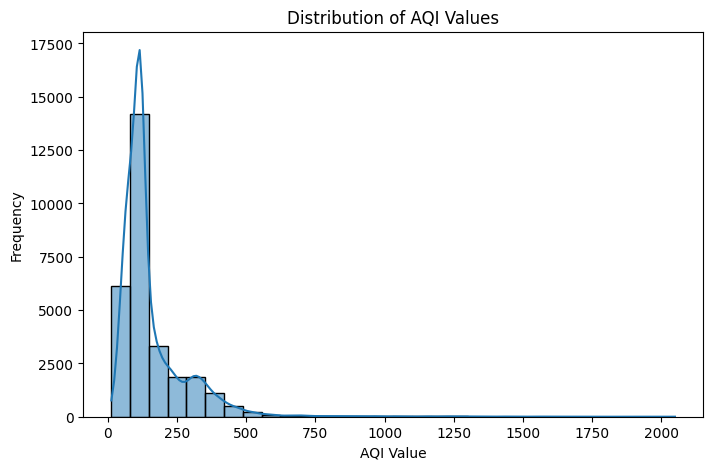

```python
#DISTRIBUTION ANALYSIS
plt.figure(figsize=(8,5))

sns.histplot(
    air_quality["AQI"],
    bins=30,
    kde=True
)

plt.xlabel("AQI Value")
plt.ylabel("Frequency")
plt.title("Distribution of AQI Values")

plt.show()
```

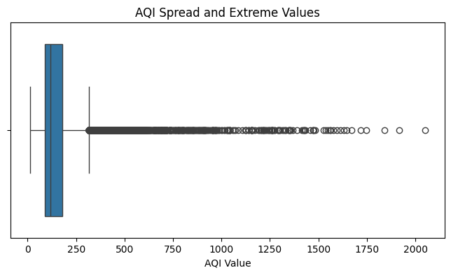

```python
plt.figure(figsize=(8,4))

sns.boxplot(
    x=air_quality["AQI"]
)

plt.xlabel("AQI Value")
plt.title("AQI Spread and Extreme Values")

plt.show()
```

Visualization Justification:

Histogram is selected because it shows where most AQI readings are concentrated.

Boxplot is selected because it clearly identifies extreme pollution values.

Observations:

1. Most AQI values are concentrated in the lower and moderate range.
2. Some very high AQI readings exist which increase the average AQI.

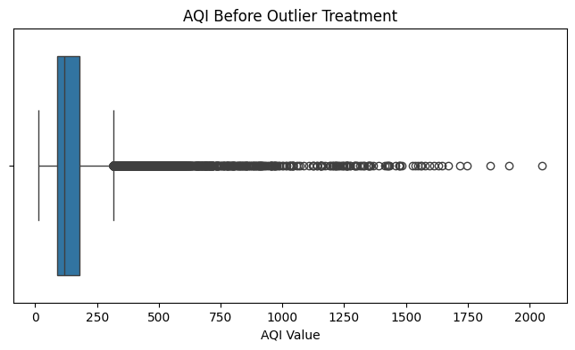

```
Number of extreme AQI values: 3192
```

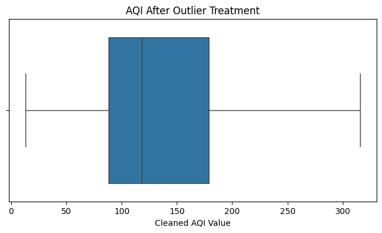

```python
# Task 5: Outlier Detection and Treatment


# AQI before treatment

plt.figure(figsize=(8,4))

sns.boxplot(
    x=air_quality["AQI"]
)

plt.title("AQI Before Outlier Treatment")
plt.xlabel("AQI Value")

plt.show()



# Calculate IQR

Q1 = air_quality["AQI"].quantile(0.25)

Q3 = air_quality["AQI"].quantile(0.75)


IQR = Q3 - Q1


lower_limit = Q1 - 1.5 * IQR

upper_limit = Q3 + 1.5 * IQR



# Identify extreme values

outliers = air_quality[
    (air_quality["AQI"] < lower_limit) |
    (air_quality["AQI"] > upper_limit)
]


print("Number of extreme AQI values:",
      outliers.shape[0])



# Treat outliers using capping method

air_quality["AQI_cleaned"] = np.where(
    air_quality["AQI"] > upper_limit,
    upper_limit,
    air_quality["AQI"]
)



# After treatment visualization

plt.figure(figsize=(8,4))

sns.boxplot(
    x=air_quality["AQI_cleaned"]
)

plt.title("AQI After Outlier Treatment")
plt.xlabel("Cleaned AQI Value")

plt.show()
```

Extreme values were detected using the IQR method.

Instead of deleting records, capping was applied because very polluted days may be real environmental events.

Capping reduces the influence of extreme values while preserving the dataset size for future machine learning.